# Patterns in FONSIs: Deliverable 6

Categorical-exclusion opportunities from prior decarbonization Findings of No Significant Impact

Published

September 27, 2026

## Executive Summary

**NoteKey Findings**

- **A data-driven grid of 52 technology × action cells** — every clean-energy FONSI placed by its technology (from D3) and its LLM-labeled action verb — resolves to 21 adopt · 2 expand · 17 develop candidate cells (plus 12 already covered; all pending CE-coverage verification). No category is hand-picked: the verdicts fall out of the grid.
- **Expand is the single strongest lever — transmission upgrades within existing right-of-way:** 26 bounded, low-impact FONSIs across 12 states (BLM, DOE, and the power-marketing administrations) match a transmission CE (TVA’s #17 / #19), but a subset of long rebuilds exceeds its ~25-mile cap — so the move is to expand that CE, not adopt it as-is.
- **Most decarbonization FONSIs lean on committed mitigation** — 310 of 451 (69%) are *mitigated* FONSIs, so a CE built from them must encode the recurring mitigations as design criteria, not rely on case-by-case commitments.
- **Adopting a peer agency’s CE is well-precedented:** of 2,105 existing federal CEs, 130 action-families are already shared across two or more agencies.
- **Net-new CEs are visible in the grid itself** — 15 codifiable *develop* cells recur with no close existing CE (demonstration / pilot facilities are the cross-cutting standout). A further frontier is the 92 FONSIs whose action the model could only label *“other”* — a recommended clustering next step.

This report delivers:

> Technical support for new regulatory categorical exclusion development: identifying patterns in FONSIs.

# Methodology

The deliverable runs three analyses, each on a different data source. They are not a single funnel — only Analysis 1 starts from the full FONSI corpus; Analysis 2 works from the mitigated subset of it, and Analysis 3 works from the existing federal CE catalog (not FONSIs at all).

| Analysis | Data source | Scope |
| --- | --- | --- |
| **1. Scaling CEs (develop, expand, or adopt)** | Decarb EAs with FONSIs | 215/451 projects (~48%) |
| **2. Mitigated FONSIs** | Decarb Mitigated FONSIs | 310 of 451 projects (69%) |
| **3. Current federal CE catalog** | Existing federal CE catalog | 2,105 CEs |

Each analysis’s scope is summarized above; its step-by-step Methodology (the callout at the top of each analysis) and its own caveats appear with that analysis, below.

How the pipeline fits together: the table organizes the deliverable by data source, while the stages below trace the code pipeline end to end. It is one deterministic chain with a single exception, the LLM enrichment, the one billable step, which runs standalone and is cached, so the rest of the chain re-runs without it.

1 · Assemble the FONSI corpus

Build the decarbonization **EA → FONSI** corpus (the 451 clean-energy FONSIs) with each FONSI's evidence spans (`01`)

↓

2 · Enrich each FONSI · billable LLM pass · standalone

`03_enrich_llm.py` (Claude Sonnet) extracts each FONSI's action, numeric limits, mitigation dependence, and significance thresholds — quote-verified. Run once, outside the deterministic re-run; its output is cached and reused

↓

3 · Build the technology × action grid

`10_action_label.py` labels each FONSI's action verb and pairs it with its Deliverable 3 technology, placing every FONSI in a grid cell

↓

4 · Match each cell to the CE catalog

Embed the existing federal CEs and score each cell's closest match by blended semantic + word-overlap similarity (`04`, `06`)

↓

5 · Resolve verdicts & apply the gates

`07_classify_and_rank.py` reads each cell as **develop / expand / adopt**, applies the eCFR **coverage gate** (verified / partial / flip-to-develop), and sorts develop cells into **main / exploratory / dropped** recurrence tiers

↓

Figures & report

`08_create_figures.R` builds the coverage map, sizing, ranking, mitigation, and CE-landscape figures this report embeds

# Analysis 1 — Scaling Categorical Exclusions (CEs)

**NoteMethodology**

1. **Data —** the 451 decarbonization EA→FONSI projects. A FONSI concludes a full Environmental Assessment, so each is a documented federal “no significant impact” determination — the evidence base for a CE.
2. **Label** each FONSI’s action verb (new-build, upgrade, exploration, demonstration…) with an LLM, and pair it with the FONSI’s Deliverable-3 technology — together these place it on the technology × action grid.
3. **Keep the bounded, low-impact subset** within each type — the small, routine projects that could plausibly be a CE (in-corridor upgrades, not major rebuilds). This is a yes/no judgment about scale, not a numeric threshold: a FONSI is kept whether or not it states an acreage or length.
4. **Match** each candidate against the existing federal CE catalog by text similarity.
5. **Compare sizes** — read the matched CE’s stated size limit (acres, miles, kV, MW, wells), where it has one, against the bounded FONSIs’ own sizes, to test whether ours exceed it. This is the only step where stated numbers matter.
6. **Classify** as develop (no existing CE covers it), expand (our FONSIs exceed the CE’s stated limit), or adopt (a CE exists, but at a different agency than the ones doing these FONSIs).

> This analysis asks how to scale Categorical Exclusions (CEs): where an agency could **adopt** a CE another agency already holds, **expand** an existing CE whose bound is too tight, or **develop** a new CE for a recurring action that no CE yet covers. It answers this exhaustively — every clean-energy FONSI is placed on a technology × action grid, and each cell is read as one of those three verdicts.

**The bottom line — three levers, read across every clean-energy technology:**

- **Expand — the strongest single opportunity.** Transmission upgrades: 26 in-corridor rebuild / reconductor FONSIs across 12 states still run as full EAs though a CE exists; its size bound is simply too tight, so the move is to widen it.
- **Adopt — broad but thin.** 21 technology × action cells already have a matching CE at another agency to adopt, but most rest on only 2–4 FONSIs, so there is no single dominant case.
- **Develop — the genuinely new gap.** 17 recurring actions have no close existing CE (15 codifiable; 2 set aside as non-codifiable). The clearest is cross-cutting: demonstration / pilot facilities recur as a gap for wind, nuclear, and other clean-energy projects, the strongest candidate for a brand-new CE. (Develop verdicts are candidates pending eCFR review; non-codifiable actions such as battery manufacturing are set aside.)

## The coverage map

Every decarbonization FONSI is categorized by its technology (an independent Deliverable-3 classification) and its action (an LLM-assigned verb), filling a grid of 52 technology × action cells. Each cell is matched against the existing federal CE catalog and read as adopt, expand, or develop. The coverage map below is the answer, up front; the three stages that follow show how every cell earned its color: build the grid, resolve each cell, then rank the opportunities:

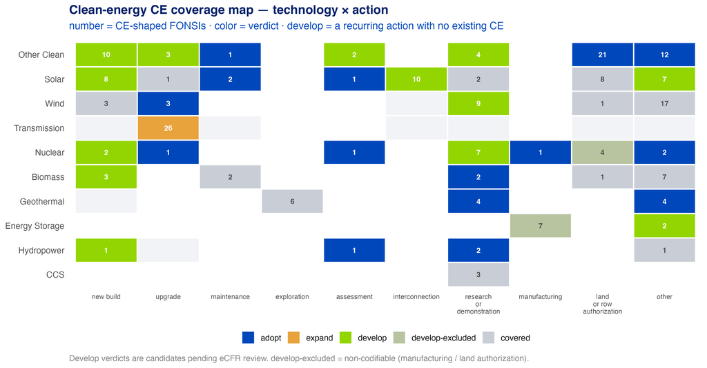

Figure 1: The clean-energy CE coverage map — every FONSI by technology × action. Color = verdict (adopt / expand / develop / already-covered); a *develop* cell is a recurring action with no existing CE. *develop-excluded* = non-codifiable (manufacturing / land authorization). Number = CE-shaped FONSIs in the cell.

The 215 CE-shaped FONSIs — the small, routine cases within these cells — are the actionable evidence carried through the rest of this analysis.

## Build the grid: label the action, keep the CE-shaped subset

A dedicated LLM pass labels each FONSI’s action verb — new-build, upgrade, maintenance, exploration, demonstration, and so on — which, paired with its technology, is what places it in a grid cell. Within each technology we then keep the bounded, low-impact subset (teal in the figure): the small, routine version that could plausibly be a CE — in-corridor work, short segments, previously disturbed land, no major new construction. These are the FONSIs we carry forward. The broader projects (grey), meaning larger or greenfield work such as major rebuilds, new corridors, and utility-scale greenfield, are set aside as not CE-shaped.

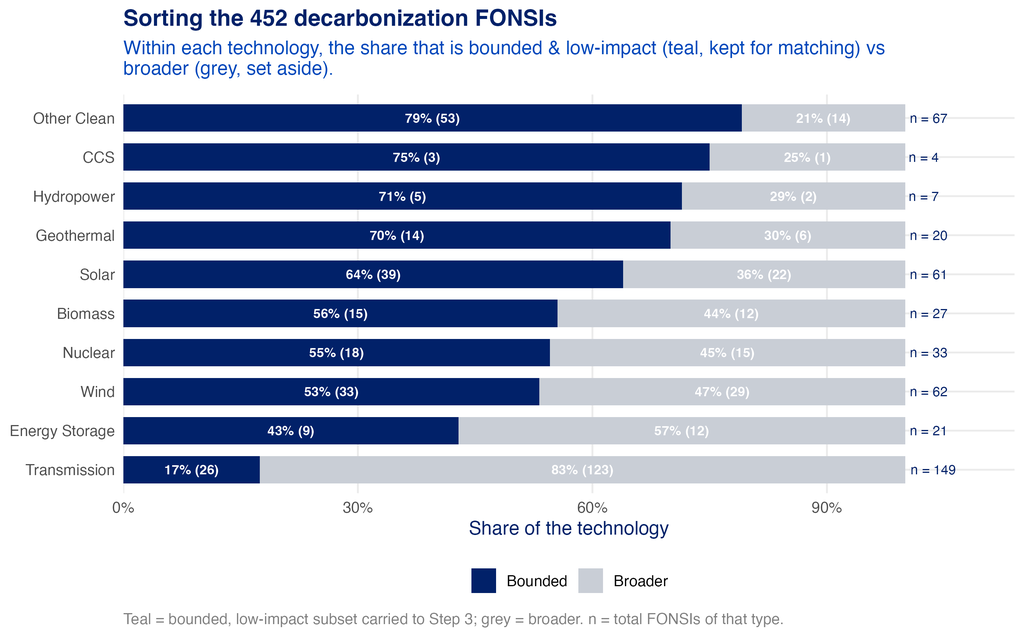

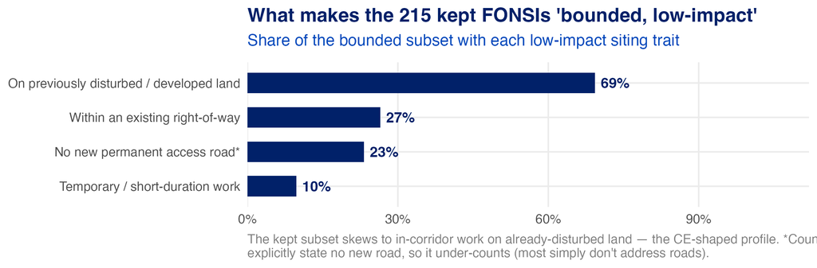

Figure 3: Share of the bounded subset with each low-impact siting trait. *The ‘no new permanent access road’ bar counts only FONSIs that explicitly say so, and therefore under-counts.

One caveat on reading this chart: the “no new permanent access road” bar is a conservative flag, firing only when a FONSI explicitly states no new road, so its low share reflects under-reporting (most FONSIs simply do not address roads), not that the rest build major new access. The two dominant, well-evidenced traits are previously disturbed land and within an existing right-of-way. (Beyond what the chart shows, the enrichment also records whether each action tiers from a programmatic review and its overall bounded, low-impact judgment, further signals behind the same conclusion.)

## Resolve each cell: match to the CE catalog, then apply the rule

Each cell is compared against all 2,105 existing federal CEs to find its closest match (a 0–1 text-similarity score blending semantic meaning and word overlap, a ranking aid, not a percent of matching text). That match then resolves the cell to a verdict by a three-question rule:

```
%%{init: {"flowchart": {"htmlLabels": true}} }%%
flowchart TD
  A["For each tech × action cell:<br/>is there a close matching CE?"]
  A -->|no| D["<b>Develop</b><br/>no CE exists — write a new one"]
  A -->|yes| B{"Do our FONSIs exceed the<br/>CE's stated size bound?"}
  B -->|yes| E["<b>Expand</b><br/>widen the existing CE"]
  B -->|no| C{"Is it held at a different agency<br/>than the ones running these EAs?"}
  C -->|yes| AD["<b>Adopt</b><br/>that agency adopts the CE"]
  C -->|no| CV["already covered<br/>(drop)"]
```

The coverage map above is this rule applied to every cell. The match score is a ranking aid, not the verdict: scores are uncalibrated, so read them comparatively. A cell scored against a random, unrelated CE sits near the grey baseline (≤ ~0.20); the cells that resolve to adopt / expand sit well above it, while the develop cells fall closest to it, since no existing CE covers them. Every verdict is a candidate pending eCFR confirmation, not a legal finding.

Table 1: Closest existing categorical exclusion to each recurring tech × action cell (n ≥ 5 CE-shaped FONSIs), by text similarity — a ranking aid, pending eCFR verification.

| Tech × action | Verdict | Closest existing CE (held by) | Similarity |
| --- | --- | --- | --- |
| Geothermal — exploration | already_covered | BLM---2-13 (Bureau of Land Management) | 0.61 |
| Other Clean — land or row authorization | adopt | BLM---5-49 (Bureau of Land Management) | 0.53 |
| Solar — land or row authorization | already_covered | BLM---4-25 (Bureau of Land Management) | 0.47 |
| Wind — other | already_covered | DOE-1--5-89 (Department of Energy) | 0.45 |
| Biomass — other | already_covered | DOE-1--5-91 (Department of Energy) | 0.44 |
| Other Clean — other | adopt | DOE-1--5-85 (Department of Energy) | 0.42 |
| Transmission — upgrade | expand | USDA-1-2-2-58 (Department of Agriculture) | 0.41 |
| Solar — other | develop | DOE-1--5-88 (Department of Energy) | 0.39 |
| Solar — interconnection | develop | TVA---1-15 (Tennessee Valley Authority) | 0.39 |
| Wind — research or demonstration | develop | DOE-1--5-89 (Department of Energy) | 0.39 |
| Energy Storage — manufacturing | develop | DOE-1--4-72 (Department of Energy) | 0.37 |
| Other Clean — new build | develop | BLM---4-25 (Bureau of Land Management) | 0.36 |
| Solar — new build | develop | BLM---4-25 (Bureau of Land Management) | 0.35 |
| Nuclear — research or demonstration | develop | NIST--1-5-15 (National Institute of Standards and Technology) | 0.35 |

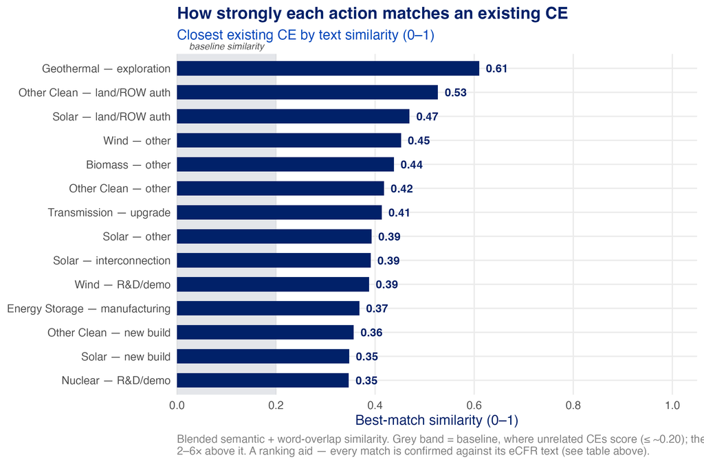

## Rank the opportunities

With every cell resolved, the opportunities (the adopt, expand, and develop cells) are ranked by priority so the reader can see which to pursue first. Each gets a transparent score (0–1) summing six factors; the bar length is the priority and the colors show why:

- Novelty — a brand-new CE (develop) outranks expanding or adopting one.
- Volume — how many bounded FONSIs back it (more evidence ranks higher).
- Agency/state spread — how widely the action recurs (broader = more agencies benefit).
- Has size limits — whether we can state a numeric bound (easier to write the CE).
- Low mitigation dependence — less reliance on case-by-case mitigation (a cleaner CE).
- Recurring action type — a flat baseline every grid cell shares (it lifts all scores equally, so it does not change the order).

Because the default score weights novelty most, the net-new (develop) candidates rank highest: *Solar — other*, *Other Clean — upgrade*, and *Wind — demonstration / pilot* (nuclear’s demonstration cell ranks lower down). *Transmission upgrade*, the highest-volume single cell (the *expand* lever in the Findings below), sits a few places behind them; it leads only when raw volume is weighted most (the next table).

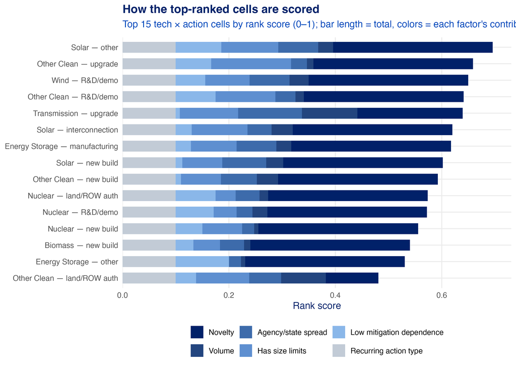

Figure 5: Each candidate’s rank score, broken into its six contributing factors (bar length = total priority). Only cells with ≥ 2 CE-shaped FONSIs are ranked — empty cells are excluded.

The weights are a judgment call, so rather than a few hand-picked weightings we run a sensitivity analysis: 2,000 weight vectors drawn uniformly from the 6-weight simplex (Dirichlet), recomputing each cell’s rank every draw (`07_classify_and_rank.py` `rank_sensitivity()` → `rank_sensitivity.csv`). The table below shows each cell’s point rank (the reported weights) beside the median rank and inter-quartile band across all draws, and how often it lands in the top 3. A wide band means the cell’s position is weight-sensitive, so the leaders should be read as a band of strong candidates, not a precise order:

Table 2: Weight-sensitivity of the opportunity ranking over 2,000 Dirichlet-sampled weight vectors (cells with ≥ 2 CE-shaped FONSIs). Point rank uses the reported weights; median [p25–p75] and % top-3 summarize the full sweep. Cells with a wide IQR are weight-sensitive — treat the top group as a band.

| Cell | Point rank | Median rank | IQR band | % top-3 |
| --- | --- | --- | --- | --- |
| Solar — other | 1 | 2 | 1–2 | 90% |
| Other Clean — upgrade | 2 | 4 | 2–8 | 48% |
| Wind — research or demonstration | 3 | 5 | 4–7 | 22% |
| Other Clean — research or demonstration | 4 | 4 | 3–8 | 37% |
| Transmission — upgrade | 5 | 5 | 1–13 | 45% |
| Solar — interconnection | 6 | 9 | 7–12 | 1% |
| Energy Storage — manufacturing | 7 | 9 | 6–13 | 1% |
| Solar — new build | 8 | 11 | 8–17 | 3% |
| Other Clean — new build | 9 | 13 | 9–18 | 0% |
| Nuclear — land or row authorization | 10 | 11 | 7–15 | 1% |
| Nuclear — research or demonstration | 11 | 11 | 8–16 | 1% |
| Nuclear — new build | 12 | 15 | 11–18 | 0% |

## Findings: three CE opportunities

**These are candidate matches, not coverage determinations.** Each pairing below is a text-similarity match between a recurring FONSI action and an existing CE at another agency; it flags where adoption is worth reviewing, not that the CE legally covers the action. Every match is pending verification against the current eCFR / agency CE text; treat the verdicts as a prioritized review list, not a legal conclusion.

The grid’s 52 cells resolve to 21 adopt · 2 expand · 17 develop, plus 12 already covered. (Both expand cells are transmission; the second (transmission new-build) has no CE-shaped FONSIs in this corpus, so the Expand finding below covers upgrades.) The three opportunity types follow in priority order, each self-contained below, covering what the opportunity is, the evidence behind it, and the recommended action.

### Expand — transmission upgrades (the strongest opportunity)

The single highest-volume opportunity is transmission upgrades: 26 in-corridor transmission FONSIs across 12 Western states match an existing CE, but a subset of long rebuilds runs past its ~25-mile cap, so the move is to widen that cap rather than adopt the CE as-is.

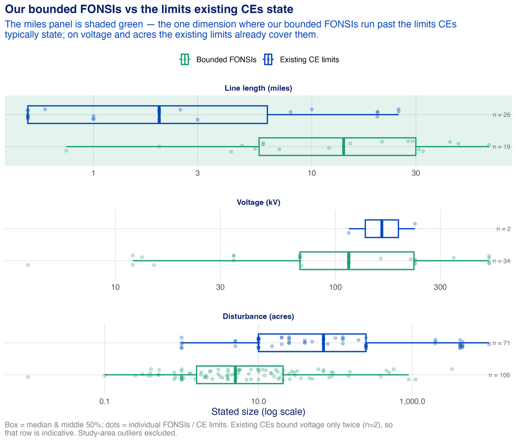

Figure 6: Context from the **full** CE catalog: bounded transmission FONSIs vs all stated CE size limits (log scale, boxplot + cases). The miles panel is shaded where our FONSIs exceed the limits CEs typically state — the transmission *expand* case. Study-area outliers excluded.

The transmission case splits into two candidate CEs.

The strongest-evidenced case: 59 transmission-upgrade FONSIs for in-corridor work, across BLM, the power-marketing administrations, NNSA, and others in 12 Western states. TVA already categorically excludes this work under two exclusions, by work type:

- CE #17 (modify in place) covers reconductoring, uprating, equipment swaps, and limited pole replacement, with no length limit.
- CE #19 (rebuild) covers replacing the line’s structures within the existing right-of-way, capped at 25 miles.

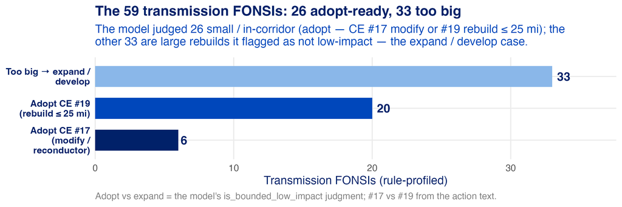

Figure 7: The transmission FONSIs split by the model’s low-impact judgment: adopt-ready (CE #17 modify / #19 rebuild ≤25 mi) vs the large rebuilds that are too big for the existing CE (expand / develop). #17-vs-#19 inferred from the action text.

Both exclusions, verbatim (key phrases bolded):

> *CE #17 — modify.* **Routine modification, repair, and maintenance** of, and **minor upgrade** of and addition to, **existing transmission infrastructure** … transmission line **uprate, modification, reconductoring** … and **limited pole replacement**. *(New access roads outside the right-of-way are capped at 1 mile — a road limit, not a line limit.)*

> *CE #19 — rebuild.* The **rebuilding** of transmission lines within or contiguous to **existing rights-of-way** involving generally **no more than 25 miles** in length and no more than 125 acres of expansion of the existing right-of-way.

The table below lists sample FONSIs from different agencies, each with a verbatim excerpt from the cited record showing the in-corridor reconductoring/rebuild work these CEs cover. Each row names the source document (EA or FONSI) and page, and the project title links to the full record in the document explorer.

Table 3: Sample bounded transmission-upgrade FONSIs with verbatim, source-verified excerpts (titles link to the document explorer).

| Agency | Project title | Source | Excerpt |
| --- | --- | --- | --- |
| Candidate CE #17 — reconductor / in-place upgrade |  |  |  |
| Bureau of Land Management | [PG&E Yosemite to Exchequer Line Upgrades](https://huggingface.co/spaces/kaseyzapatka/nepa-document-explorer?pid=42be2009dae242695d90fc05c1391084) | EA, p. 2 | “Under the proposed action, the BLM would grant a **right-of-way** (ROW) amendment to PG&Es **existing** ROW grant. The amendment would allow for repairs and required facility **upgrades** to the Exch… |
| Bureau of Land Management | [Lugo-Victorville Remedial Action Scheme Project](https://huggingface.co/spaces/kaseyzapatka/nepa-document-explorer?pid=11722075b65ec8fe146b527d580cee02) | EA, p. 16 | “New Distribution Pole/Work Area **Replace** and/or **Remove** **Existing** Distribution Pole/Work Area **Existing** Manhole/Work Area New Manhole/Work Area Guard Structure Helicopter Landing Zone Und… |
| Candidate CE #19 — rebuild (≤ 25 mi) |  |  |  |
| Western Area Power Administration | [Davis–Kingman Tap 69-kV Transmission Line Rebuild](https://huggingface.co/spaces/kaseyzapatka/nepa-document-explorer?pid=ba2da0d34550f2a77a14b8a5a2c1c384) | EA, p. 30 | “Western proposes to **rebuild** the Davis–Kingman Tap 69-kV Transmission Line by: • **Removing** the **existing** wood pole H-frame structures and conductors • Excavating for new structure foundation… |
| Power Marketing Administration | [Allston to Astoria Rebuild Project](https://huggingface.co/spaces/kaseyzapatka/nepa-document-explorer?pid=ce40b4826b2872b6883ce09ae26f562c) | EA, p. 14 | “The Proposed Action would **rebuild** the approximately 22-mile-long Allston-Driscoll No. 2 and the approximately 21-mile-long Driscoll-Astoria No. 1 transmission lines. Along both lines, the work wo… |
| Bonneville Power Administration | [Albany-Burnt Woods and Santiam-Toledo Pole Replacement Project](https://huggingface.co/spaces/kaseyzapatka/nepa-document-explorer?pid=e95ba6ba5ec6175cb3d2db6f3f2684ab) | FONSI, p. 1 | “BPA is proposing to **replace** aging and deteriorating wood pole structures and associated structural components on the **existing** Albany-Burnt Woods 115-kV No. 1 transmission line and along a por… |
| Bureau of Land Management | [Bald Mountain to Dewey 69/12kV Upgrade/Rebuild](https://huggingface.co/spaces/kaseyzapatka/nepa-document-explorer?pid=00d687eeb657f0797ba2b92fed2cf3cd) | EA, p. 12 | “Under the Proposed Action, BLM will approve the amendment to expand APS's ROW width from 15 feet to 65 feet, and APS will **upgrade** and **replace** its **existing** infrastructure on BLM land in a … |

### Adopt — cross-agency matches (broad but thin)

Adoption is the broadest but thinnest opportunity: 21 cells resolve to adopt, where a close CE exists at another agency the doing-agency could take up, and the 2023 FRA now permits exactly that. Each adopt/expand cell’s top-5 CE matches have now been adjudicated against the current eCFR text (`ce_ecfr_verify.py`): 10 cells are verified (a matching CE confirmed in the eCFR), 12 partially cover (the CE is close but bounded or text-unverifiable, as agency-procedure CEs not in the eCFR are capped here), and one match, Hydropower new-build, did not cover (its nearest CEs were off-scope offshore oil/gas exclusions), so it was reclassified as develop. But most adopt cells are thin: only 9 have ≥ 2 CE-shaped FONSIs (the table below); the rest rest on a single FONSI. Treat adopt as a verified but often thin menu of matches, not one dominant case.

Table 4: Candidate adopt opportunities (adopt cells with ≥ 2 CE-shaped FONSIs): bounded actions with a close CE match at one agency but run as full EAs at others (matches pending eCFR verification).

| Tech × action | Low-impact FONSIs | Existing CE (held by) | eCFR coverage | Agencies that could adopt it | States |
| --- | --- | --- | --- | --- | --- |
| Other Clean — land or row authorization | 21 | [BLM---5-49](https://www.doi.gov/media/document/doi-nepa-appendix-2) — Bureau of Land Management | partial | DOE | 6 |
| Other Clean — other | 12 | [DOE-1--5-85](https://www.ecfr.gov/current/title-10/chapter-X/part-1021) — Department of Energy | verified (eCFR) | PMA | 10 |
| Biomass — research or demonstration | 2 | [BOEM---3-22](https://www.doi.gov/media/document/doi-nepa-appendix-2) — Bureau of Ocean Energy Management | verified (eCFR) | DOE | 2 |
| Hydropower — research or demonstration | 2 | [BOEM---2-7](https://www.doi.gov/media/document/doi-nepa-appendix-2) — Bureau of Ocean Energy Management | partial | DOE | 3 |
| Geothermal — other | 4 | [BLM---2-13](https://www.doi.gov/media/document/doi-nepa-appendix-2) — Bureau of Land Management | verified (eCFR) | DOE | 4 |
| Geothermal — research or demonstration | 4 | [BLM---2-13](https://www.doi.gov/media/document/doi-nepa-appendix-2) — Bureau of Land Management | partial | DOE | 4 |
| Solar — maintenance | 2 | [DA---3-35](https://www.denix.osd.mil/nepa/denix-files/sites/55/2025/06/DOD-NEPA-Procedures-APPENDIX-A_FINAL.pdf) — U.S. Army | verified (eCFR) | BLM | 1 |
| Wind — upgrade | 3 | [DOE-1--5-89](https://www.ecfr.gov/current/title-10/chapter-X/part-1021) — Department of Energy | verified (eCFR) | BLM | 2 |
| Nuclear — other | 2 | [NRC---1-11](https://www.ecfr.gov/cgi-bin/text-idx?SID=5bddd0accdfc420ea5e3e2067fb33a61&mc=true&node=se10.2.51_122&rgn=div8) — Nuclear Regulatory Commission | verified (eCFR) | DOE | 1 |

**eCFR coverage** is the adjudicated cell-best over the top-5 CEs: *verified* = a matching CE confirmed in the current eCFR; *partial* = close but bounded or held only in an agency-procedure document (not the eCFR). **Thin-evidence flag:** most adopt cells rest on only 2–4 low-impact FONSIs — verified coverage does not make a thin cell a robust finding.

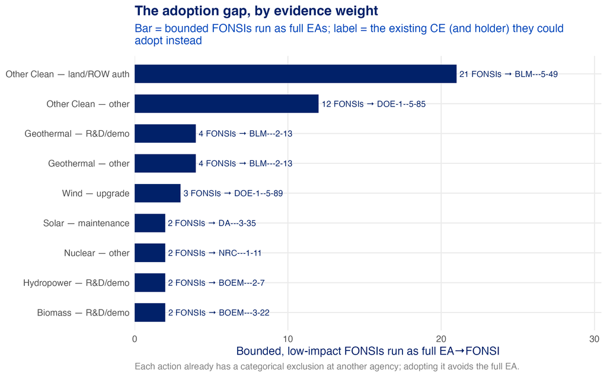

Figure 8: Per adopt candidate: bounded FONSIs run as full EAs, and the existing CE they could adopt.

### Develop — net-new gaps

The genuinely new opportunity is a develop gap: 17 cells recur with no close existing CE, invisible under the old hand-picked categories, and 15 of them are codifiable, so the move is to draft a new CE. Every develop cell sits below the 0.40 match line: the closest existing CE isn’t close enough to adopt.

The cross-cutting standout is demonstration / pilot facilities, a develop gap for wind (9), nuclear (7), and other clean-energy (4) projects; one new CE could cover research / demonstration across technologies. (For geothermal and biomass the same action already has a matchable CE, so it resolves to adopt, and the method discriminates.) The rest are more technology-specific: solar interconnection, small new-builds. Non-codifiable actions such as battery manufacturing and land permits are set aside; a CE codifies a physical action.

Table 5: Candidate develop opportunities after the recurrence gate: recurring tech × action cells with no close existing CE (closest match below the 0.40 line). Cells with ≥ 5 CE-shaped FONSIs are **main**; 3–4 are **exploratory**; cells below 3 are dropped from the client shortlist. Non-codifiable cells (battery manufacturing, land authorization) excluded.

| Tech × action | Tier | CE-shaped FONSIs | States | Closest CE (similarity) |
| --- | --- | --- | --- | --- |
| Solar — interconnection | main | 10 | 4 | 0.39 |
| Other Clean — new build | main | 10 | 5 | 0.36 |
| Wind — research or demonstration | main | 9 | 7 | 0.39 |
| Solar — new build | main | 8 | 7 | 0.35 |
| Solar — other | main | 7 | 6 | 0.39 |
| Nuclear — research or demonstration | main | 7 | 3 | 0.35 |
| Other Clean — research or demonstration | exploratory | 4 | 4 | 0.34 |
| Other Clean — upgrade | exploratory | 3 | 3 | 0.37 |
| Biomass — new build | exploratory | 3 | 3 | 0.37 |

Recurrence gate (`07_classify_and_rank.py`): **6 main** + **3 exploratory** cells shown; **6 cells dropped** for having fewer than 3 CE-shaped FONSIs (they remain in the grid for coloring but are not a client develop recommendation). All develop cells fall below the 0.40 match line.

## Timing and the FRA caveat

This makes the finding a historical one. The corpus is almost entirely pre-FRA, so it shows where full EAs were run before the adoption shortcut existed, identifying where adoption review is likely worthwhile, not that agencies are still running these EAs today. So the recommendation is that pre-FRA EAs indicate likely adoption opportunities, pending a post-FRA refresh. Before any client action, that refresh is required: check current CE-adoption use, recent (post-June-3-2023) EA/FONSI recurrence, and any agency implementation guidance since the FRA. Until then these are candidates to review, not a claim about current agency behavior.

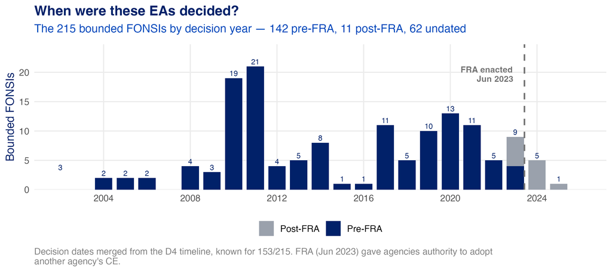

Figure 9: The bounded FONSIs by decision year (D4 timeline), relative to the FRA’s June 2023 CE-adoption authority.

# Analysis 2 — Mitigated FONSIs

**NoteMethodology**

1. **Data —** the mitigated FONSIs: the subset whose “no significant impact” finding depends on committed mitigation rather than the action being inherently low-impact (310 of 451, 69%).
2. **Flag** each FONSI’s mitigation dependence from the LLM read — *case-specific-dependent* (the finding rests on committed mitigation) vs *design-feature-only* (inherently bounded) vs *none*.
3. **Measure** the mitigated share and the resource areas where mitigation recurs, within each action type.
4. **Read for CE design —** a mitigation that recurs consistently across a class is a codifiable CE design criterion; an idiosyncratic one is a disqualifier.

> **Mitigated FONSIs** imply that the project will have “no significant impact” if the applicant commits to some form of mitigation. This analysis systematically examines the language surrounding mitigated FONSIs to determine if there are patterns of actions that are routinely mitigated and if we can capture those recurring mitigations as a new CE.

**Mitigation dependence is a risk screen, not a disqualifier.** A mitigated FONSI does not mean the action class is unsuitable for a CE. It means a defensible CE for that class would need to encode the recurring avoidance/minimization measures as design criteria and exclude cases that hinge on project-specific commitments. So a high mitigated share is a flag to read the measures, not a veto.

## How “mitigated” was determined

The model reads each FONSI once and pulls four things (whether the finding depends on mitigation, what role that mitigation plays, the committed measures themselves, and the agency’s “significant if X” thresholds), and we then test each for recurrence: a measure or threshold that recurs across a class can become a CE design criterion, an idiosyncratic one cannot:

```
flowchart LR
  A["451 FONSIs"] --> B["Claude reads each one:<br/>the finding + the<br/>committed conditions"]
  subgraph X["What Claude extracts"]
    direction TB
    C["Does the finding depend on<br/>mitigation — and what role<br/>does that mitigation play?"]
    D["The mitigation<br/>measures themselves"]
    E["The agency's<br/>'significant if X' thresholds"]
  end
  subgraph Y["Does it recur across projects?"]
    direction TB
    F["Most depend on<br/>case-specific mitigation"]
    G["Measures do NOT repeat<br/>→ can't codify"]
    H["Thresholds DO repeat<br/>→ the codifiable CE bounds"]
  end
  B --> C & D & E
  C --> F
  D --> G
  E --> H
  style X fill:transparent,stroke:#012169
  style Y fill:transparent,stroke:#012169
```

For every one of the 451 FONSIs the model read the finding and the committed conditions and set three fields:

- Whether it is mitigated — does the “no significant impact” finding depend on committed mitigation, or is the action inherently low-impact?
- What role the mitigation plays — one of: none (inherently low-impact), design-feature-only (impacts avoided by the project’s own bounded design), case-specific-dependent (the finding rests on committed, project-specific mitigation), permit/consultation condition (required by another regime, not the FONSI’s basis), monitoring-only, or unclear.
- The significance threshold — the agency’s explicit “would be significant if it exceeded X” statements, captured verbatim. These are a CE’s natural numeric bounds and, unlike the project-specific mitigation measures, they recur across projects.

The supporting mitigation text is captured verbatim and 97%-quote-verified, and each FONSI is tagged with the resource areas its mitigation addresses (biological, water, cultural…) from a fixed vocabulary, so we can measure which recur.

## The share of FONSIs that are mitigated

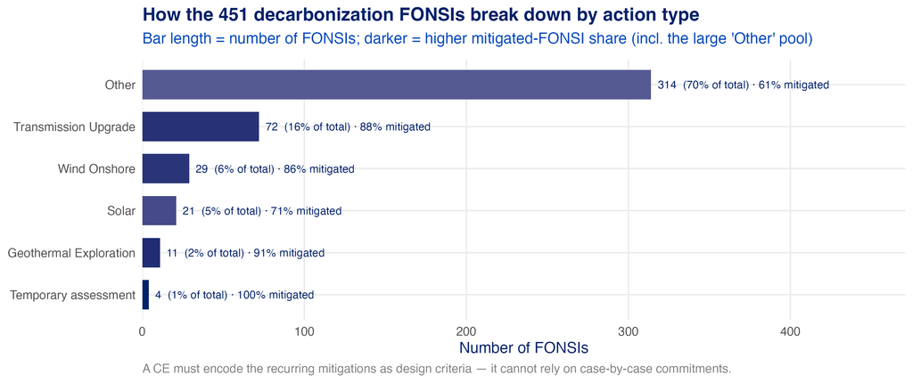

Figure 10: Mitigated-FONSI share by action type across all 451 FONSIs — not limited to the Analysis-1 candidates.

Across the whole corpus, then, the share reaching “no significant impact” only with committed mitigation:

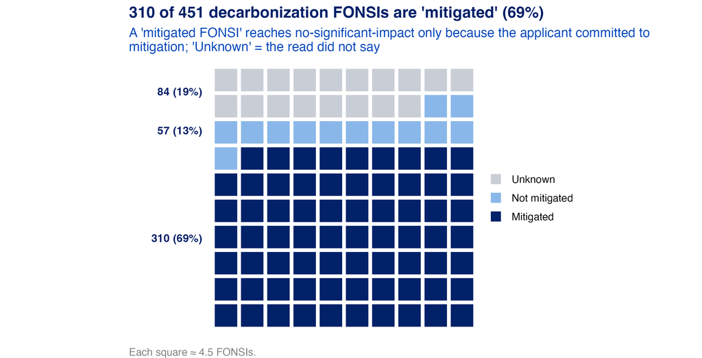

Figure 11: How many of the decarbonization FONSIs reach ‘no significant impact’ only with committed mitigation.

### Examples: the committed mitigation

The model’s mitigation summaries for FONSIs tagged case-specific-dependent are shown below so the read can be checked directly. These are LLM-extracted summaries, not verbatim quotes; the verbatim, quote-verified text lives in the boundary table below and in `evidence_cited`:

Table 6: Sample committed-mitigation summaries (LLM-extracted from the cited FONSI/EA — model summaries, not verbatim quotes; titles link to the document explorer).

| Project Title | Committed mitigation (LLM summary; project-specific measures in bold) |
| --- | --- |
| [Salem-Albany Transmission Line Rebuild Project](https://huggingface.co/spaces/kaseyzapatka/nepa-document-explorer?pid=fda50a34e982e5bc55d1eda9670184c0) | A Mitigation Action Plan is attached to the FONSI listing all committed mitigation measures. Measures include: coordinating construction activities (including helicopter use and tree removal) with Ank… |
| [Hills Creek‐Lookout Point Transmission Line Rebuild Project](https://huggingface.co/spaces/kaseyzapatka/nepa-document-explorer?pid=1fcfcf9f3dceaee67c9fe422f21dc5bd) | A Mitigation Action Plan was prepared committing BPA and contractors to measures including: minimizing construction footprint especially in Forest Service and Corps habitat restoration areas, **wetlan… |
| [Palisades-Goshen Transmission Line Reconstruction Project](https://huggingface.co/spaces/kaseyzapatka/nepa-document-explorer?pid=f4f0f310c854e90116a5ae55070eb0e9) | Mitigation measures include restricting construction to the minimum necessary work area, ongoing **weed control** on the ROW, installing bird flight diverters on the new line where it crosses the Sout… |
| [Raymond-Cosmopolis Transmission Line Rebuild Project](https://huggingface.co/spaces/kaseyzapatka/nepa-document-explorer?pid=9d2e419390dc5822163bf942907cc9b3) | A detailed Mitigation Action Plan (MAP, Appendix D of the EA) was developed and incorporated into the FONSI, obligating BPA to implement all mitigation measures. Key measures include: instream work **… |
| [San Emidio Geothermal Exploration Project](https://huggingface.co/spaces/kaseyzapatka/nepa-document-explorer?pid=c5fe1f66720f2025f628443bbdedd6b7) | Mitigation includes: no surface occupancy within 2 miles of known sage grouse leks; avoidance of sage grouse **nesting**/brood-rearing/winter habitat within 0.6–2 miles of leks; reclamation of disturb… |

## The role mitigation plays

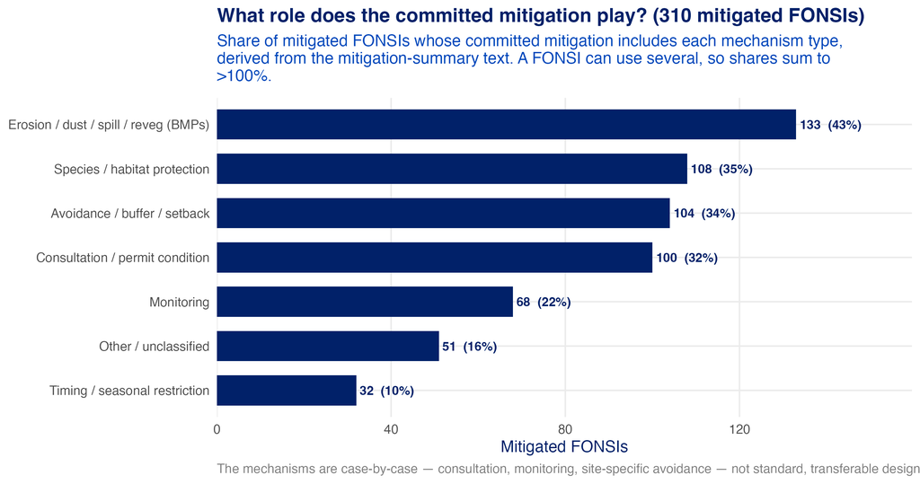

Figure 12: The roles mitigation plays across the 310 mitigated FONSIs — the share whose committed mitigation includes each mechanism type (a FONSI can use several, so shares sum to more than 100%). Derived from the mitigation-summary text.

### The dependence is overwhelmingly case-specific

Of the 310 mitigated FONSIs, 309 are case-specific-dependent: the finding rests on project-specific mitigation, not on the action being inherently low-impact. The contrast with the next section is the point, as the significance thresholds do recur across projects, which is what makes them, not the measures, the codifiable part.

> A note on interpretation: `is_mitigated_fonsi` and `mitigation_dependence` are near-equivalent judgments: the model almost always pairs “the finding depends on mitigation” with “that mitigation is project-specific.” So this is one consistent signal, not two independent confirmations. The FONSIs it reads as inherently low-impact (design-feature-only or none) are exactly the ones it flags as not mitigated. The substantive finding stands: when a FONSI leans on mitigation, that mitigation is tailored to the project, not a standard, transferable design feature.

### The mitigation language is project-specific

The measures themselves are written per project: SHPO consultation here, raptor-nest buffers there, site-specific erosion plans elsewhere. Breaking every mitigation summary into 2–3 word phrases and counting them, no phrase recurs across projects. A CE therefore cannot copy any one project’s measures. What does recur is the resource area the mitigation protects (consistently biological, soils, water, and cultural), and those are what a defensible CE would distill into standing design criteria.

Table 7: Mitigated-FONSI counts and the recurring resource areas by candidate action type (sorted by FONSIs examined).

| Action | FONSIs | Mitigated | Recurring resource areas |
| --- | --- | --- | --- |
| Transmission — new_build | 27 | 20 | biological(23); soils_geology(13); cultural(10); visual(8); water(8) |
| Transmission — upgrade | 26 | 24 | biological(22); soils_geology(17); cultural(15); water(11); visual(5) |
| Transmission — land_or_row_authorization | 26 | 18 | biological(18); soils_geology(11); cultural(5); water(4); public_health(4) |
| Other Clean — land_or_row_authorization | 21 | 13 | biological(13); soils_geology(8); cultural(4); public_health(4); water(3) |
| Transmission — maintenance | 18 | 15 | biological(16); water(12); soils_geology(11); cultural(7); air_quality(4) |
| Wind — other | 17 | 11 | biological(10); soils_geology(9); water(9); cultural(4); noise(3) |
| Other Clean — other | 12 | 5 | air_quality(8); public_health(8); water(5); soils_geology(3); other(1) |
| Other Clean — new_build | 10 | 9 | biological(10); cultural(4); soils_geology(4); water(4); air_quality(3) |
| Wind — interconnection | 10 | 8 | biological(9); soils_geology(6); water(4); other(4); noise(3) |
| Solar — interconnection | 10 | 7 | biological(7); soils_geology(5); cultural(4); water(3); visual(2) |
| Transmission — other | 10 | 5 | biological(5); water(3); air_quality(2); soils_geology(2); visual(1) |
| Wind — research_or_demonstration | 9 | 4 | biological(7); visual(3); soils_geology(3); air_quality(2); water(2) |
| Solar — new_build | 8 | 7 | biological(6); soils_geology(4); visual(3); cultural(3); water(2) |
| Transmission — interconnection | 8 | 6 | soils_geology(6); biological(6); visual(3); cultural(3); public_health(3) |
| Solar — land_or_row_authorization | 8 | 5 | biological(5); soils_geology(3); water(1); visual(1); other(1) |
| Energy Storage — manufacturing | 7 | 5 | soils_geology(5); public_health(4); noise(3); water(2); air_quality(2) |
| Biomass — other | 7 | 4 | air_quality(7); noise(4); soils_geology(3); water(3); biological(3) |
| Nuclear — research_or_demonstration | 7 | 2 | public_health(3); biological(2); soils_geology(2); air_quality(2); cultural(1) |
| Solar — other | 7 | 1 | biological(1); air_quality(1); cultural(1); soils_geology(1); water(1) |
| Geothermal — exploration | 6 | 6 | soils_geology(5); biological(5); cultural(3); public_health(2); air_quality(2) |
| Geothermal — other | 4 | 2 | water(2); soils_geology(2); biological(2); noise(1); visual(1) |
| Geothermal — research_or_demonstration | 4 | 1 | air_quality(1); water(1); public_health(1) |
| Nuclear — land_or_row_authorization | 4 | 1 | public_health(1); biological(1); cultural(1) |
| Other Clean — research_or_demonstration | 4 | 1 | water(3); air_quality(3); soils_geology(1); biological(1); public_health(1) |
| Wind — upgrade | 3 | 3 | biological(3); soils_geology(2); cultural(1); other(1); water(1) |
| Wind — new_build | 3 | 2 | cultural(1); biological(1); soils_geology(1); noise(1); public_health(1) |
| CCS — research_or_demonstration | 3 | 2 | biological(2); other(1); soils_geology(1); water(1) |
| Biomass — new_build | 3 | 2 | water(1); air_quality(1); transportation(1); soils_geology(1); other(1) |
| Other Clean — upgrade | 3 | 1 | biological(2); visual(1); cultural(1); soils_geology(1); public_health(1) |
| Biomass — maintenance | 2 | 2 | biological(2); water(1); soils_geology(1); cultural(1) |
| Other Clean — assessment | 2 | 2 | soils_geology(2); water(2); visual(1); biological(1) |
| Hydropower — research_or_demonstration | 2 | 2 | biological(2); cultural(2); water(1) |
| Geothermal — new_build | 2 | 2 | cultural(2); biological(2); water(1); soils_geology(1); public_health(1) |
| Biomass — research_or_demonstration | 2 | 1 | noise(2); air_quality(2); public_health(2) |
| Solar — maintenance | 2 | 1 | biological(2); noise(1) |
| Nuclear — new_build | 2 | 1 | water(2); cultural(2); noise(1); biological(1); air_quality(1) |
| Nuclear — other | 2 | 1 | public_health(2); transportation(1); other(1) |
| Energy Storage — other | 2 | 0 | air_quality(1); cultural(1); visual(1) |
| Solar — research_or_demonstration | 2 | 0 |  |
| Biomass — land_or_row_authorization | 1 | 1 | soils_geology(1); water(1); biological(1); cultural(1); recreation(1) |
| Nuclear — assessment | 1 | 1 | soils_geology(1); biological(1); recreation(1); transportation(1) |
| Hydropower — upgrade | 1 | 1 | soils_geology(1); water(1); air_quality(1) |
| Hydropower — other | 1 | 1 | biological(1); water(1); public_health(1) |
| Hydropower — new_build | 1 | 1 | cultural(1); biological(1); visual(1); public_health(1) |
| Wind — land_or_row_authorization | 1 | 1 | biological(1); water(1); soils_geology(1); recreation(1); public_health(1) |
| Solar — upgrade | 1 | 1 | water(1); biological(1); visual(1); soils_geology(1) |
| Solar — assessment | 1 | 1 | biological(1); cultural(1); soils_geology(1); air_quality(1) |
| Nuclear — manufacturing | 1 | 0 |  |
| Hydropower — assessment | 1 | 0 | air_quality(1); biological(1); transportation(1) |
| Nuclear — upgrade | 1 | 0 | public_health(1); transportation(1) |
| Other Clean — maintenance | 1 | 0 | biological(1) |
| Transmission — research_or_demonstration | 1 | 0 | public_health(1); other(1) |

## The agency’s “significant if X” thresholds

Alongside mitigation, the enrichment captures the agency’s explicit significance-threshold statements: “would be significant if it exceeded X,” “an EIS would be required unless Y.” Those sentences are a CE’s natural numeric bounds.

### Boundary language: the verbatim statements

Each is a verbatim, span-verified quote; real examples:

Table 8: Verbatim significance-threshold statements — the agencies’ own ‘would (not) be significant’ counterfactuals (the argument bolded). These are a CE’s natural bounds; titles link to the document explorer.

| Project Title | Significance-threshold statement (argument in bold) |
| --- | --- |
| [Davis–Kingman Tap 69-kV Transmission Line Rebuild](https://huggingface.co/spaces/kaseyzapatka/nepa-document-explorer?pid=ba2da0d34550f2a77a14b8a5a2c1c384) | Biological impacts would be considered **significant if** project implementation would result in any of the following: • Loss to any population of wildlife that would jeopardize the continued existenc… |
| [Gila to North Gila Transmission Line Rebuild and Upgrade Project](https://huggingface.co/spaces/kaseyzapatka/nepa-document-explorer?pid=00a456d42d45bca81408478d7f65dcaa) | Impacts to cultural resources and Native American religious concerns **would be significant** if: The Project results in adverse impacts to NRHP-eligible properties that cannot be satisfactorily mitig… |
| [DOE’s Proposed Financial Assistance to Dow Kokam MI, LLC to Manufacture Advanced Lithium Polymer Batteries for Hybrid and Electric Vehicles at Midland, Michigan](https://huggingface.co/spaces/kaseyza… | The loss of habitat **would not be a significant** impact to any plant or animal species, as the project site is relatively small, adjacent to large industrial and commercial developments, and isolate… |
| [Dillon Road at Interstate 10 Multi-Tenant Wireless Broadband Communications Site](https://huggingface.co/spaces/kaseyzapatka/nepa-document-explorer?pid=ca8cd724d693f72c629b052c9eb05581) | none of these impacts **would be significant** at the local scale or cumulatively because of the small-scale footprint of the project and the project design features and mitigation measures that would… |
| [BP Solar Array Project](https://huggingface.co/spaces/kaseyzapatka/nepa-document-explorer?pid=0937f67244dd987d646b6998b0458635) | electric and magnetic fields associated with the proposed action **would be significant**ly below the 200 mG and 0.5 kilovolts per foot (1.6 kV/m) guidelines, and **would not be expected to have any a… |

These are candidate CE bounds straight from the agencies’ own findings — the thresholds a new or adopted CE would be written to stay within.

And here is the key contrast with the mitigation measures: unlike the measures, these threshold conditions recur across projects, which is exactly what makes them codifiable. The most-common phrases in the agencies’ “would be significant if …” statements:

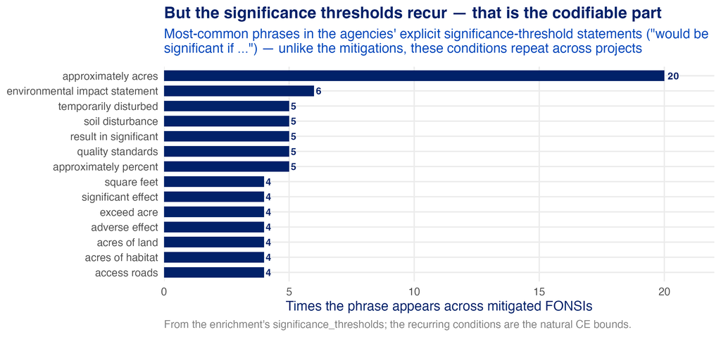

Figure 13: Most-frequent phrases in the agencies’ explicit significance-threshold statements across the mitigated FONSIs. Unlike the project-specific mitigation measures (which do not recur), these conditions repeat — the natural, codifiable CE bounds.

# Analysis 3 — Review of existing federal Categorical Exclusions

**NoteMethodology**

1. **Data —** the existing federal CE catalog (the [CE Explorer export](https://ce.permitting.innovation.gov/) — 2,105 CEs across 78 agency units, each linking to its eCFR source).
2. **Compare** every CE to every other by text similarity.
3. **Flag** near-duplicates that recur at more than one agency.
4. **Group** those into shared “action families.”
5. **Read** each CE’s stated numeric limits, where it has any → what is already covered and how routinely agencies share the same CE (the precedent for *adopt*).

> This analysis reviews all 2,105 **existing federal Categorical Exclusions** across 78 agency units for patterns and insights.

## The CE landscape, by department and agency

The catalog is concentrated: four of the 35 departments hold half of all 2,105 CEs:

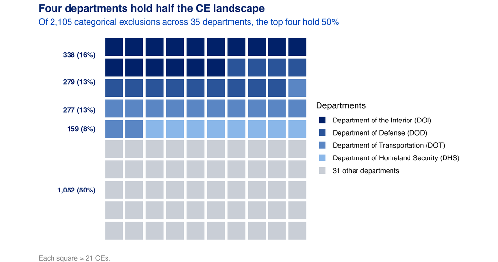

Figure 14: Each square ≈ 21 CEs; the four largest departments fill half the grid.

Within those departments, the individual agencies (the four big departments in teal):

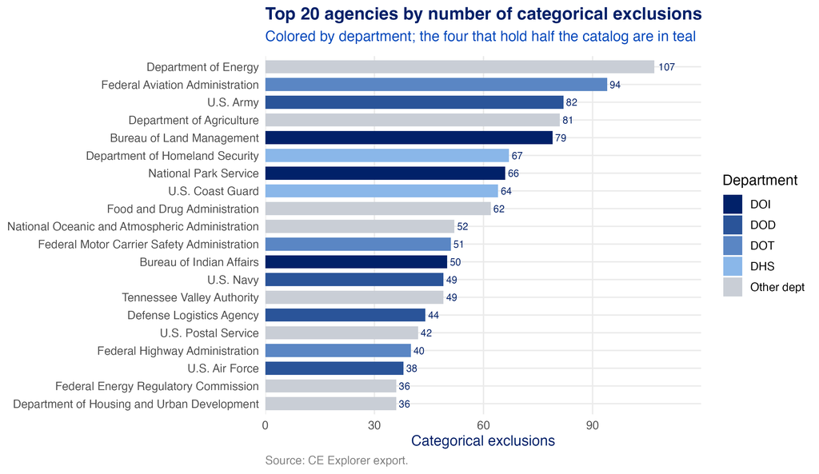

Figure 15: Top 20 agencies by number of categorical exclusions, colored by department.

## Numeric bounds are rare and scattered

Only 86 of 2,105 CEs state an explicit numeric limit. The other ~2,019 bound the action qualitatively.

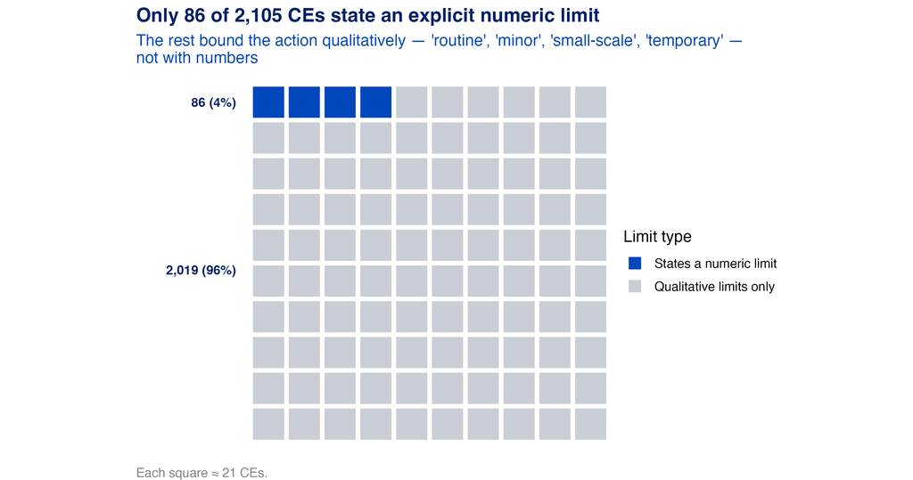

Figure 16: Of all 2,105 CEs, only 86 carry an explicit numeric limit; the rest are bounded with words.

And the few that do carry a number are themselves scattered: acres and miles dominate, but every CE picks a different value. The single most common acreage limit (10 acres) is used by only 14 of the 71, and the stated limits run all the way from 1 to 10,000 acres. There is no common threshold to expand against:

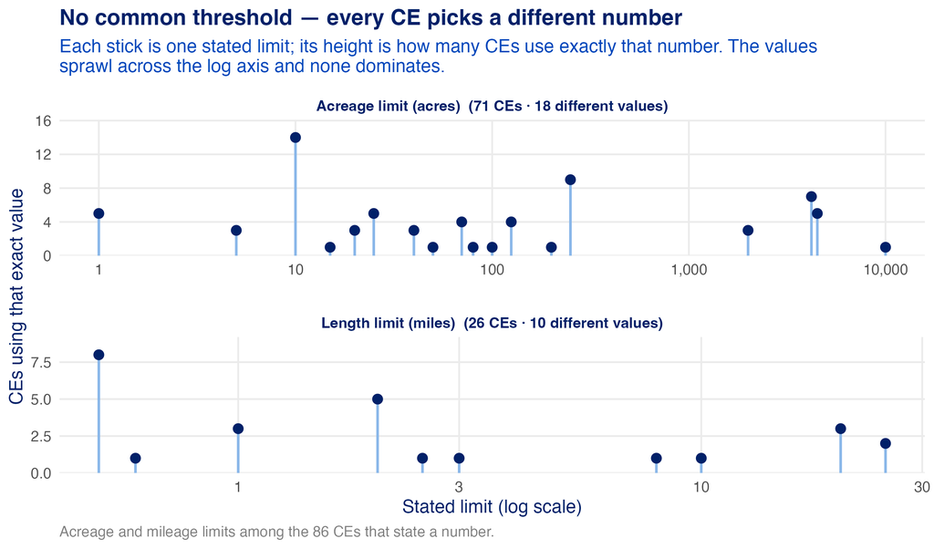

Figure 17: Every stated acre/mile limit among the 86 CEs that have one; stick height = how many CEs use exactly that value. The values sprawl across the log axis and none dominates.

So a numeric “expand the stated limit” argument has little precedent to lean on: the transmission cells are the exception in Analysis 1 (they exceed CE #19’s 25-mile cap); for the other cells, qualitative coverage gaps stay unverified rather than numerically exceeded.

### The non-numeric limits

Most CEs bound scope with words, not numbers, consistent in spirit but disjointed in form, each agency phrasing it differently:

Table 9: How existing CEs bound scope without numbers.

| Limiter type | Example CE language (verbatim) |
| --- | --- |
| Routine / minor | (l) Routine procurement of goods and services (complying with applicable procedures for sustainable or “green” procurement) to support operations and infrastructure, including routine utility services… |
| Small-scale / limited | A4. Approving and issuing grants for social services, education and training programs, including but not limited to support for Head Start, senior citizen programs, drug treatment programs, and fundin… |
| Temporary / short-term | (f) Supportive services that include health care and housing services, permanent housing placement, day care, nutritional services, collection of payment for services, short-term payments for rent/mor… |
| Within existing footprint | B2 Transportation of personnel, detainees, equipment, and evidentiary materials in wheeled vehicles over existing roads or jeep trails established by Federal, Tribal, State, or local governments, incl… |

## How closely the CEs relate

Each point below is one CE laid out by text similarity (t-SNE of the embeddings), colored by its k-means family and labeled by the family’s distinctive phrases. The CE text does not split into cleanly separated clusters: the silhouette is low and flat across every *k* (see the k-selection figure below), so the k = 8 families are a readability grouping of the layout, not a natural optimum. Even so, recognizable families emerge (real property & rights-of-way, data collection / geophysical survey, hazardous-materials storage & disposal, airport layout plans, goods & services, and regulatory/guidance actions), and many recur across different departments, which is the precedent for adopt.

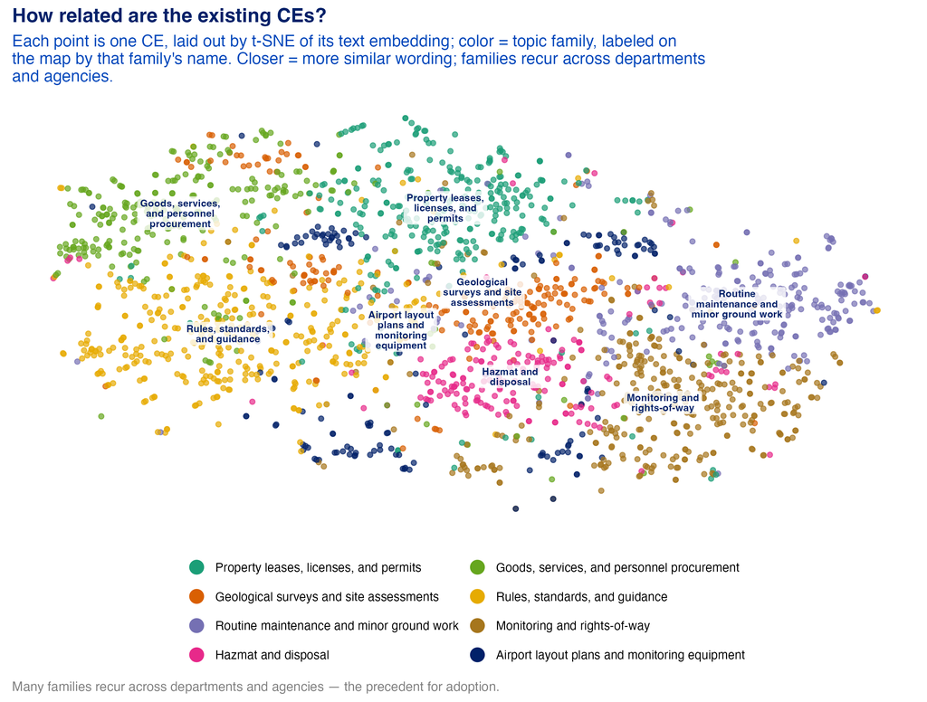

Figure 18: Every CE laid out by text similarity (t-SNE), colored by k-means family and labeled by its distinctive phrases. Closer = more similar wording. Many families recur across departments and agencies — the precedent for adoption.

The eight families, the topic each represents, and their distinctive keywords:

Table 10: The eight CE families — topic and distinctive keywords.

| Topic | Keywords |
| --- | --- |
| Property leases, licenses, and permits | leases, easements, licenses, permits, real property |
| Geological surveys and site assessments | geological / geophysical surveys, site assessments, data collection |
| Goods, services, and personnel procurement | procurement, supportive / health / housing services, personnel |
| Rules, standards, and guidance | rules, safety standards, product certification, labeling |
| Routine maintenance and minor ground work | routine facility maintenance, groundskeeping, dredging |
| Hazmat and disposal | disposal of property / fixtures / structures, hazardous materials |
| Monitoring and rights-of-way | monitoring equipment, rights-of-way, resident relocations |
| Airport layout plans and monitoring equipment | FAA airport layout plans, equipment installation, surveillance |

How many families to draw is a judgment call, because the CE text has no natural cluster count — the appendix figure shows it:

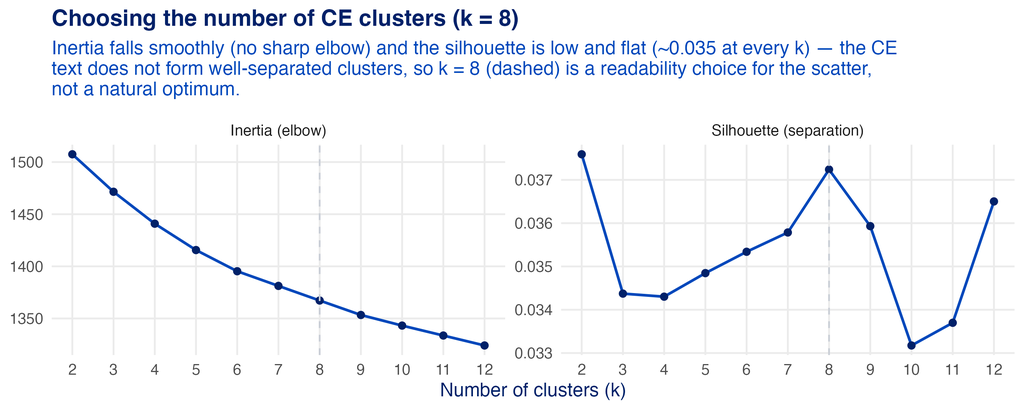

Figure 19: k-selection for the CE clustering: inertia (elbow) falls smoothly and the silhouette is low and flat (~0.035 at every k), so k = 8 is a readability choice, not a natural optimum.

## Cross-agency duplication — the precedent for *adopt*

The same low-impact action is frequently excluded by several agencies under near-identical language. 317 CEs have a near-twin at a different agency, forming 130 shared “action families.” Adopting a peer’s CE, the exact move Analysis 1 recommends, is not unusual; it is how the landscape already works. This shows adoption is common in the CE corpus; it does not verify that the shortlisted adopt matches actually cover the D6 actions, which remains the pending eCFR check.

The chart below shows how the twin families distribute across departments — each bar is the number of families shared by *exactly* that set of departments:

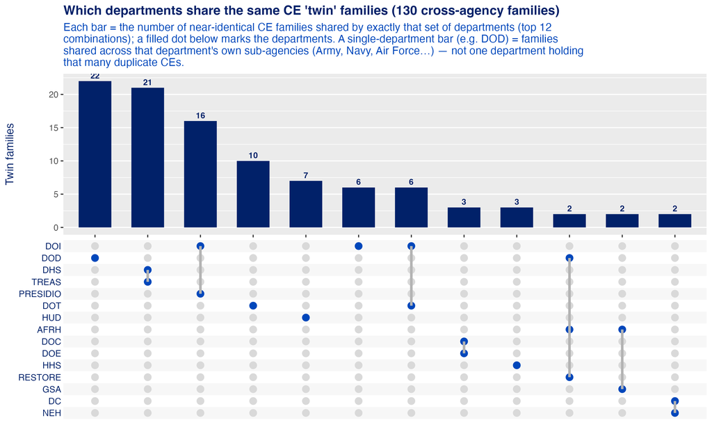

Figure 20: Cross-agency CE ‘twin’ families by the set of departments that share them (top 12 combinations). A filled dot marks each department in the combination — the adopt precedent, visualized.

Each row in the table below is one shared family (not a single example): the action, how many agencies use a near-identical CE for it, and a few of those agencies.

Table 11: Action families already categorically excluded by two or more agencies.

| Shared action | Agencies sharing it | e.g. |
| --- | --- | --- |
| 3. Routine procurement of goods and services. | 8 | AFRH, DOD - DA, DOD - DAF, DOD - DLA, DOD - DON, DOD - DT... |
| (g) Normal personnel, fiscal, and administrative activities involving civilian personnel (recruiting, processing, paying, and records keeping). | 7 | AFRH, DOD - DA, DOD - DAF, DOD - DLA, DOD - DTRA, DOD - M... |
| (USDA-34d-USFS) Post-fire rehabilitation activities, not to exceed 4,200 acres (such as tree planting, fence replacement, habitat restoration, heritage site restoration, repair of roads and trails, an… | 6 | DOI - BIA, DOI - BLM, DOI - BOR, DOI - NPS, DOI - USFWS, ... |
| 34. Demolition, disposal, or improvements involving buildings or structures when done in accordance with applicable regulations including those regulations applying to removal of asbestos, PCBs, and o… | 5 | AFRH, DOD - DON, DOD - DTRA, DOD - MDA, NEH |
| (NR4) Preparation of policies, procedures, manuals, and other guidance documents for which the environmental effects are too broad, speculative, or conjectural to lend themselves to meaningful analysi… | 5 | DOC - NIST, DOC - NOAA, DOC - NTIA, DOI, DOJ - FBI |
| *E2 New construction upon or improvement of land where all of the following conditions are met: (a) The structure and proposed use are compatible with applicable Federal, Tribal, State, and local plan… | 5 | DHS, DOD - MDA, DOJ - FBI, NEH, TREAS |

The largest shared families are mundane (procurement, personnel, routine maintenance), which is the point: when an action is genuinely low-impact, agencies converge on a shared CE. The decarbonization actions in Analysis 1 are simply ones where that convergence hasn’t happened yet.

## Where net-new CEs come from

Net-new CEs are not empty here — the grid surfaces 15 codifiable *develop* cells: recurring technology × action combinations with no close existing CE. The cross-cutting standout is demonstration / pilot facilities, which recur as a develop gap for wind (9), nuclear (7), and other clean-energy (4) projects, the single strongest candidate for a brand-new CE. (For geothermal and biomass, that same action already has a matchable CE, so it resolves to adopt, and the method discriminates.) These gaps were invisible under the old hand-picked five categories, which by construction only held well-trodden actions that already had a CE somewhere.

A further frontier sits outside the named action verbs: of the 451 gridded FONSIs, the model could only label 92 with the catch-all action “other” (funding, studies, efficiency work, and the like). This deliverable did not decompose that bucket; it is a residual of un-named actions, not an examined pool. More net-new CEs plausibly live there, but confirming that requires the recommended next step: cluster those “other” FONSI action descriptions to surface recurring categories no one has named yet.

# Caveats, limitations, and run manifest

The full caveats, next steps, assumptions, and sensitivity notes for this deliverable now live on the dedicated Coverage & Limitations page.

## Run manifest & data completeness

Table 12

**Run:** Claude `claude-sonnet-4-6` · schema `d6_enrich_schema_v5` · 451/452 FONSIs enriched · quote-verification 97.1% · 1 no-evidence row excluded

| Field | Null / missing | Treated as |
| --- | --- | --- |
| `is_mitigated_fonsi` | 85 | unknown (not mitigated=FALSE) |
| `is_bounded_low_impact` | 21 | unknown (not bounded=FALSE) |
| `decision_date` (D4) | 113 | undated (shown separately) |
| verified action quote | 13 | flagged; excluded from 'source-verified' tables |
| `disturbance_acres` | 226 | no stated acreage |
| `line_miles` | 381 | no stated length |

Null booleans are read as unknown, never as `FALSE`; the no-evidence row is carried with a status flag, not silently dropped.

# Supplementary analyses

These extend the three findings with the full LLM-extracted evidence. They are exhibits — none changes the grid, the verdicts, or the headline numbers above.

## A develop opportunity, worked end to end

The transmission adopt case (above) shows what an adopt recommendation looks like on the evidence. Here is the parallel for a develop cell, a recurring low-impact action with no close existing CE, so both verdict types land concretely.

Table 13: Worked develop example: the wind research/demonstration cell — a recurring action with no close CE (best match below 0.40). Representative FONSIs with their LLM-extracted action and siting facts.

| Project | Agency | State | Action |
| --- | --- | --- | --- |
| National Wind Technology Center Site Operation | Department of Energy | "Colorado" | The Department of Energy proposes to operate the National Wi |
| University of Maine’s Deepwater Offshore Float | Department of Energy | "Maine" | The University of Maine proposes to deploy two one-third-sca |
| Virginia Offshore Wind Technology Advancement | Bureau of Ocean Energy Management | "Virginia" | BOEM approved a Research Activities Plan (RAP) for the Virgi |
| Kansas State University’s Zond Wind Energy Pro | Energy Programs | "Kansas" | DOE proposes to provide federal funding to Kansas State Univ |
| Smart Grid, Center for Commercialization of El | Department of Energy | "Texas" | DOE is providing a federal financial assistance grant to the |
| University of Maine’s Deepwater Offshore Float | Department of Energy | "Maine" | DOE would authorize the University of Maine (UMaine) to expe |

Cell **Wind — research or demonstration** — verdict **develop** (9 CE-shaped FONSIs, tier *main*), closest existing CE similarity **0.39** (below the 0.40 adopt line). A new CE here would codify small research/demonstration wind installations — no existing agency CE covers them, so this is *develop*, not adopt.

## Full size distribution vs. every bounded CE cap

The transmission expand case is the one numeric expand; extending the same size-vs-cap test across all bounded CEs shows where else FONSIs run past a stated cap (a raise-the-cap signal).

Table 14: Every (cell, metric) where the matched CE states a numeric cap, with the FONSI size distribution and the share exceeding it. `suggested_cap` is the 90th percentile of the in-corpus distribution.

| Tech × action | Metric | CE cap | FONSIs | Median | P90 | # over cap | % over | Suggested cap |
| --- | --- | --- | --- | --- | --- | --- | --- | --- |
| Biomass land or row authorization | acres | 250 | 1 | 500.0 | 500.0 | 1 | 100% | 500 |
| Nuclear new build | acres | 25 | 1 | 900.0 | 900.0 | 1 | 100% | 900 |
| Other Clean new build | acres | 1 | 4 | 28.8 | 41.8 | 4 | 100% | 42 |
| Solar other | acres | 10 | 5 | 19.1 | 50.4 | 3 | 60% | 50 |
| Transmission upgrade | miles | 25 | 11 | 27.7 | 47.0 | 6 | 55% | 47 |
| Solar new build | acres | 10 | 4 | 10.7 | 40.4 | 2 | 50% | 40 |
| Wind new build | acres | 10 | 2 | 13.0 | 22.6 | 1 | 50% | 23 |
| Transmission upgrade | acres | 10 | 14 | 5.4 | 135.0 | 6 | 43% | 135 |
| Geothermal exploration | acres | 20 | 3 | 14.8 | 19.8 | 1 | 33% | 20 |
| Solar interconnection | kv | 230 | 6 | 195.5 | 422.5 | 2 | 33% | 422 |
| Transmission upgrade | kv | 230 | 19 | 115.0 | 500.0 | 3 | 16% | 500 |
| Solar interconnection | acres | 125 | 7 | 5.5 | 201.3 | 1 | 14% | 201 |
| Wind other | mw | 10 | 10 | 0.9 | 3.7 | 1 | 10% | 4 |
| Wind other | acres | 10 | 12 | 1.0 | 6.7 | 1 | 8% | 7 |

## Post-FRA recurrence (corpus-answerable)

The corpus is almost entirely pre-FRA. Restricting to CE-shaped FONSIs with a known decision date, the count decided after the FRA cut (2023-06-03) is small, but this is confounded by ingestion lag, not evidence of low current activity.

Table 15: CE-shaped FONSIs by decision date relative to the FRA cut (2023-06-03), top candidate cells. Low post-FRA counts reflect incomplete 2024–2025 ingestion, not necessarily low current activity; current CE-adoption usage and agency guidance need external sources.

| Tech × action | CE-shaped | Dated | Post-FRA | Pre-FRA | Undated |
| --- | --- | --- | --- | --- | --- |
| Transmission upgrade | 26 | 16 | 2 | 14 | 10 |
| Other Clean new build | 10 | 9 | 2 | 7 | 1 |
| Solar interconnection | 10 | 10 | 1 | 9 | 0 |
| Solar new build | 8 | 6 | 1 | 5 | 2 |
| Solar other | 7 | 6 | 1 | 5 | 1 |
| Nuclear research or demonstration | 7 | 4 | 1 | 3 | 3 |
| CCS research or demonstration | 3 | 2 | 1 | 1 | 1 |
| Solar maintenance | 2 | 2 | 1 | 1 | 0 |
| Other Clean upgrade | 3 | 1 | 1 | 0 | 2 |
| Other Clean land or row authorization | 21 | 19 | 0 | 19 | 2 |

## Within-cell themes for the “other”-action FONSIs

The 92 FONSIs the action model could only label *“other”* are clustered on local embeddings to name their sub-action structure. This is descriptive only — it changes no verdict.

Table 16: Local-embedding clusters over the 92 action==‘other’ FONSIs (within-cell refinement, no verdict change). Labels are the top TF-IDF terms per cluster (c-TF-IDF-style: per-cluster mean of document TF-IDF vectors).

| Theme | FONSIs | Tech groups |
| --- | --- | --- |
| biomass; facility; energy; waste; ethanol | 22 | Biomass, Nuclear, Other Clean, Solar, Transmission |
| wind; turbine; wind turbine; single; single wind | 20 | Wind |
| manufacturing; gas; battery; energy storage; storage | 14 | Energy Storage, Other Clean, Transmission |
| solar; photovoltaic; guarantee; loan guarantee; scale solar | 13 | Other Clean, Solar |
| geothermal; drilling; nuclear; testing; construction | 12 | Energy Storage, Geothermal, Hydropower, Nuclear, Other Clean, Transmission |
| standards; efficiency; rulemaking; energy; energy efficiency | 8 | Nuclear, Other Clean, Transmission |
| restoration; bpa; tidal; conservation; delta | 3 | Hydropower, Other Clean |

## Significance-threshold language (retrieval coverage)

A deterministic pass over finding/condition/resource spans retrieves explicit significance-threshold phrasing (the `span_type=='boundary'` layer is nearly empty, so this searches the richer spans).

Table 17: Significance-threshold phrases retrieved across finding/condition/resource evidence spans, by phrase.

| Threshold phrase | Matches |
| --- | --- |
| would require an eis | 464 |
| would be significant if | 159 |
| not to exceed | 157 |
| no new access road | 54 |
| extraordinary circumstance | 10 |
| within existing right-of-way | 2 |

**447 distinct projects** carry at least one threshold phrase across **846** retrieved spans.

# Reproduction

The report is LLM-backed: action facts, numeric limits, mitigation, and significance thresholds all come from a one-pass enrichment of the FONSIs. That enrichment is a prerequisite and is not regenerated by `_run.py`. From the repository root in the `nepa` conda environment:

```bash
# 1. LLM enrichment (REQUIRED first; billable Anthropic pass, --dry-run for cost only)
#    model claude-sonnet-4-6, schema d6_enrich_schema_v5, ~451/452 FONSIs ->
#    data/analysis/deliverable06/fonsi_enrichment.parquet
conda run -n nepa python phase2/code/deliverable06/03_enrich_llm.py --workers 4

# 2. deterministic chain 01->08 (09 wires the enrichment into facts/verdicts)
conda run -n nepa python phase2/code/deliverable06/_run.py

# 3. render
quarto render phase2/reports/deliverable06.qmd
```

`_run.py` executes the numbered chain `01`→`08` (the `08_create_figures.R` figures step needs `Rscript`). Without step 1 it now aborts at `09_wire_enrichment.py`: 08 and this report read `fonsi_enrichment.parquet` unconditionally, so a deterministic build does not reproduce the reported figures and claims. Outputs are written to:

- `phase2/data/analysis/deliverable06/` — analysis parquets (verdicts, mitigation, CE landscape/clusters)
- `phase2/output/deliverable06/` — `figures/`, the slim comparison table, and `review/` drill-down tables

*Draft generated 2026-09-27 | NEPA Analysis — Phase 2, Deliverable 6*